# Letter Recognition | Assignment 2

Davide Pecchia

27/3/2018

## Introduction

One of the earliest applications of predictive analytics was automatic recognition of letters, which is used in applications like sorting mail at post offices. In this problem, we will build a model that uses attributes of images of four letters in the Roman alphabet -A, B, P, and R ~to predict which letter a particular image corresponds to.

In this problem, we have more than two classifications that are possible for each observation. Such problems are called **multi-class classification problems**. (For this particular problem readers are referred to Chapter 8 of the textbook `The Analytics Edge` and to the paper `Algorithmic Prediction of Health-Care Costs File` available into the `reading` section of the course web site)

The file `Letters.csv` contains 3116 observations, each of which corresponds to a certain image of one of the four letters A, B, P and R. The images came from 20 different fonts, which were then randomly distorted to produce the final images; each such distorted image is represented as a collection of pixels, each of which is “on” or “off”. For each such distorted image, we have available certain attributes of the image in terms of these pixels, as well as which of the four letters the image is. These variables are:

- **Letter**: The letter that the image corresponds to (A, B, P or R).
- **Xbox**: The horizontal position of where the smallest box covering the letter shape begins.
- **Ybox**: The vertical position of where the smallest box covering the letter shape begins.
- **Width**: The Width of this smallest box.
- **Height**: The height of this smallest box.
- **Onpix**: The total number of “on” pixels in the character image.
- **Xbar**: The mean horizontal position of all of the “on” pixels.
- **Ybar**: The mean vertical position of all of the “on” pixels.
- **X2bar**: The mean squared horizontal position of all of the “on” pixels in the image.
- **Y2bar**: The mean squared vertical position of all of the “on” pixels in the image.
- **XYbar**: The mean of the product of the horizontal and vertical position of all of the “on” pixels in the image.
- **X2Ybar**: The mean of the product of the squared horizontal position and the vertical position of all of the “on” pixels.
- **XY2bar**: The mean of the product of the horizontal position and the squared vertical position of all of the “on” pixels.
- **Xedge**: The mean number of edges (the number of times an “off” pixel is followed by an “on” pixel, or the image boundary is hit) as the image is scanned from left to right, along the whole vertical length of the image.
- **XedgeYcor**: The mean of the product of the number of horizontal edges at each vertical position and the vertical position.
- **Yedge**: The mean number of edges as the image is scanned from top to bottom, along the whole horizontal length of the image.
- **YedgeXcor**: The mean of the product of the number of vertical edges at each horizontal position and the horizontal position.

## Preprocessing

#### Libraries

```r
library(rpart)
library(rpart.plot)
library(randomForest)
library(caTools)
library(caret)
library(knitr)
```

#### Dataset

```r
letters <- read.csv("Dataset/Letters.csv")
str(letters)
```

```
## 'data.frame':    3116 obs. of  17 variables:
##  $ Letter   : Factor w/ 4 levels "A","B","P","R": 2 1 4 2 3 4 4 1 3 3 ...
##  $ Xbox     : int  4 1 5 5 3 8 2 3 8 6 ...
##  $ Ybox     : int  2 1 9 9 6 10 6 7 14 10 ...
##  $ Width    : int  5 3 5 7 4 8 4 5 7 8 ...
##  $ Height   : int  4 2 7 7 4 6 4 5 8 8 ...
##  $ Onpix    : int  4 1 6 10 2 6 3 3 4 7 ...
##  $ Xbar     : int  8 8 6 9 4 7 6 12 5 8 ...
##  $ Ybar     : int  7 2 11 8 14 7 7 2 10 5 ...
##  $ X2bar    : int  6 2 7 4 8 3 5 3 6 7 ...
##  $ Y2bar    : int  6 2 3 4 1 5 5 2 3 5 ...
##  $ XYbar    : int  7 8 7 6 11 8 6 10 12 7 ...
##  $ X2Ybar   : int  6 2 3 8 6 4 5 2 5 6 ...
##  $ XY2bar   : int  6 8 9 6 3 8 7 9 4 6 ...
##  $ Xedge    : int  2 1 2 6 0 6 3 2 4 3 ...
##  $ XedgeYcor: int  8 6 7 11 10 6 7 6 10 9 ...
##  $ Yedge    : int  7 2 5 8 4 7 5 3 4 8 ...
##  $ YedgeXcor: int  10 7 11 7 8 7 8 8 8 9 ...
```

```r
kable(summary(letters))
```

|  | Letter | Xbox | Ybox | Width | Height | Onpix | Xbar | Ybar | X2bar | Y2bar | XYbar | X2Ybar | XY2bar | Xedge | XedgeYcor | Yedge | YedgeXcor |
| --- | --- | --- | --- | --- | --- | --- | --- | --- | --- | --- | --- | --- | --- | --- | --- | --- | --- |
|  | A:789 | Min. : 0.000 | Min. : 0.000 | Min. : 1.000 | Min. : 0.000 | Min. : 0.000 | Min. : 3.000 | Min. : 0.000 | Min. : 0.000 | Min. :0.000 | Min. : 3.000 | Min. : 0.00 | Min. : 0.000 | Min. : 0.000 | Min. : 1.000 | Min. : 0.0 | Min. : 1.000 |
|  | B:766 | 1st Qu.: 3.000 | 1st Qu.: 5.000 | 1st Qu.: 4.000 | 1st Qu.: 4.000 | 1st Qu.: 2.000 | 1st Qu.: 6.000 | 1st Qu.: 6.000 | 1st Qu.: 3.000 | 1st Qu.:2.000 | 1st Qu.: 7.000 | 1st Qu.: 3.00 | 1st Qu.: 6.000 | 1st Qu.: 2.000 | 1st Qu.: 7.000 | 1st Qu.: 3.0 | 1st Qu.: 7.000 |
|  | P:803 | Median : 4.000 | Median : 7.000 | Median : 5.000 | Median : 6.000 | Median : 4.000 | Median : 7.000 | Median : 7.000 | Median : 4.000 | Median :4.000 | Median : 8.000 | Median : 5.00 | Median : 7.000 | Median : 2.000 | Median : 8.000 | Median : 4.0 | Median : 8.000 |
|  | R:758 | Mean : 3.915 | Mean : 7.051 | Mean : 5.186 | Mean : 5.276 | Mean : 3.869 | Mean : 7.469 | Mean : 7.197 | Mean : 4.706 | Mean :3.903 | Mean : 8.491 | Mean : 4.52 | Mean : 6.711 | Mean : 2.913 | Mean : 7.763 | Mean : 4.6 | Mean : 8.418 |
|  | NA | 3rd Qu.: 5.000 | 3rd Qu.: 9.000 | 3rd Qu.: 6.000 | 3rd Qu.: 7.000 | 3rd Qu.: 5.000 | 3rd Qu.: 8.000 | 3rd Qu.: 9.000 | 3rd Qu.: 6.000 | 3rd Qu.:5.000 | 3rd Qu.:10.000 | 3rd Qu.: 6.00 | 3rd Qu.: 8.000 | 3rd Qu.: 4.000 | 3rd Qu.: 9.000 | 3rd Qu.: 6.0 | 3rd Qu.:10.000 |
|  | NA | Max. :13.000 | Max. :15.000 | Max. :11.000 | Max. :12.000 | Max. :12.000 | Max. :14.000 | Max. :15.000 | Max. :11.000 | Max. :8.000 | Max. :14.000 | Max. :10.00 | Max. :14.000 | Max. :10.000 | Max. :13.000 | Max. :12.0 | Max. :13.000 |

Here we are creating a new column, called `IsB`, that assumes the value $Yes$ when the variable `Letter` corresponds to B while it assumes the value $No$ in the others cases.

```r
letters$IsB <- ifelse(letters$Letter == "B","Yes", "No")
letters$IsB <- as.factor(letters$IsB)
str(head(letters))
```

```
## 'data.frame':    6 obs. of  18 variables:
##  $ Letter   : Factor w/ 4 levels "A","B","P","R": 2 1 4 2 3 4
##  $ Xbox     : int  4 1 5 5 3 8
##  $ Ybox     : int  2 1 9 9 6 10
##  $ Width    : int  5 3 5 7 4 8
##  $ Height   : int  4 2 7 7 4 6
##  $ Onpix    : int  4 1 6 10 2 6
##  $ Xbar     : int  8 8 6 9 4 7
##  $ Ybar     : int  7 2 11 8 14 7
##  $ X2bar    : int  6 2 7 4 8 3
##  $ Y2bar    : int  6 2 3 4 1 5
##  $ XYbar    : int  7 8 7 6 11 8
##  $ X2Ybar   : int  6 2 3 8 6 4
##  $ XY2bar   : int  6 8 9 6 3 8
##  $ Xedge    : int  2 1 2 6 0 6
##  $ XedgeYcor: int  8 6 7 11 10 6
##  $ Yedge    : int  7 2 5 8 4 7
##  $ YedgeXcor: int  10 7 11 7 8 7
##  $ IsB      : Factor w/ 2 levels "No","Yes": 2 1 1 2 1 1
```

From now on we are using the seed 123 every time to obtain consistent and comparable results.

```r
set.seed(123)
spl <- sample.split(letters$IsB,
                   SplitRatio = 0.50)
training_set <- subset(letters, spl==TRUE)
test_set <- subset(letters, spl==FALSE)
str(spl)
```

```
##  logi [1:3116] TRUE TRUE TRUE FALSE FALSE FALSE ...
```

```r
nrow(training_set)
```

```
## [1] 1558
```

```r
nrow(test_set)
```

```
## [1] 1558
```

## Predicting the letter B

- Before building models, let us consider a baseline method that always predicts the most frequent outcome, which is “not B”. What is the accuracy of this baseline method on the test set?

```r
test_set$notB <- as.factor("No")
str(test_set)
```

```
## 'data.frame':    1558 obs. of  19 variables:
##  $ Letter   : Factor w/ 4 levels "A","B","P","R": 2 3 4 4 1 3 3 2 3 1 ...
##  $ Xbox     : int  5 3 8 2 3 8 6 5 7 2 ...
##  $ Ybox     : int  9 6 10 6 7 14 10 9 11 4 ...
##  $ Width    : int  7 4 8 4 5 7 8 7 10 4 ...
##  $ Height   : int  7 4 6 4 5 8 8 7 8 3 ...
##  $ Onpix    : int  10 2 6 3 3 4 7 7 6 2 ...
##  $ Xbar     : int  9 4 7 6 12 5 8 8 6 10 ...
##  $ Ybar     : int  8 14 7 7 2 10 5 8 11 2 ...
##  $ X2bar    : int  4 8 3 5 3 6 7 3 3 2 ...
##  $ Y2bar    : int  4 1 5 5 2 3 5 6 6 2 ...
##  $ XYbar    : int  6 11 8 6 10 12 7 10 13 9 ...
##  $ X2Ybar   : int  8 6 4 5 2 5 6 5 6 2 ...
##  $ XY2bar   : int  6 3 8 7 9 4 6 6 3 9 ...
##  $ Xedge    : int  6 0 6 3 2 4 3 3 0 2 ...
##  $ XedgeYcor: int  11 10 6 7 6 10 9 7 10 7 ...
##  $ Yedge    : int  8 4 7 5 3 4 8 6 3 3 ...
##  $ YedgeXcor: int  7 8 7 8 8 8 9 8 8 9 ...
##  $ IsB      : Factor w/ 2 levels "No","Yes": 2 1 1 1 1 1 1 2 1 1 ...
##  $ notB     : Factor w/ 1 level "No": 1 1 1 1 1 1 1 1 1 1 ...
```

```r
confusionMatrix(test_set$notB, test_set$IsB)
```

```
## Confusion Matrix and Statistics
##
##           Reference
## Prediction   No  Yes
##        No  1175  383
##        Yes    0    0
##
##                Accuracy : 0.7542
##                  95% CI : (0.732, 0.7754)
##     No Information Rate : 0.7542
##     P-Value [Acc > NIR] : 0.5137
##
##                   Kappa : 0
##  Mcnemar's Test P-Value : <2e-16
##
##             Sensitivity : 1.0000
##             Specificity : 0.0000
##          Pos Pred Value : 0.7542
##          Neg Pred Value :    NaN
##              Prevalence : 0.7542
##          Detection Rate : 0.7542
##    Detection Prevalence : 1.0000
##       Balanced Accuracy : 0.5000
##
##        'Positive' Class : No
##
```

$Accuracy=0.7542$

- Build a CART tree to predict whether or not a letter is a B, using the training set to build your model. Remember to not use the variable **Letter** as one of the independent variables in the model, as this is related to what we are trying to predict! Select reasonable parameter values for the model, and justify your parameter choices. What is the accuracy of this CART model on the test set?

```r
FormulaCART <- IsB ~ Xbox + Ybox + Width + Height + Onpix + Xbar + Ybar + X2bar + Y2bar + XYbar + X2Ybar + XY2bar + Xedge + XedgeYcor + Yedge + YedgeXcor
```

To select the proper parameters to use for the tree construction, we try different values of **minbucket** and select the minimun one that maximises the $Accuracy$

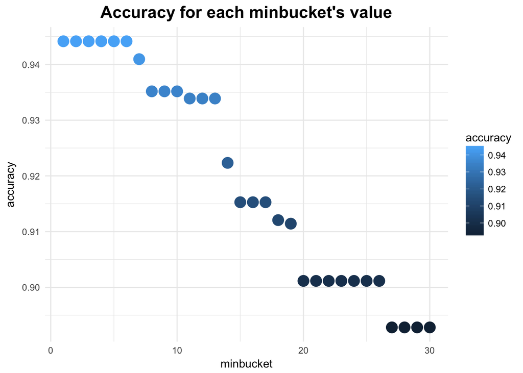

```r
var <- seq(from = 1, 30,1)
accuracy = c()
set.seed(123)
for (i in var) {
decision_tree <- rpart(formula = FormulaCART,
                      method="class",
                      data=training_set,
                      control = rpart.control(minbucket = i))
letter_prediction_CART <- predict(decision_tree,
                                  test_set,
                                  type="class")
confusion_matrix_CART <- confusionMatrix(letter_prediction_CART, test_set$IsB)
accuracy[i] <- confusion_matrix_CART$overall[1]
}
df <-data.frame(minbucket=var)
df$Accuracy <- accuracy
ggplot(df, aes(minbucket,accuracy, color=accuracy)) +geom_point(shape = 16, size = 5, show.legend = T)+theme_minimal()+ggtitle("Accuracy for each minbucket's value") +
  theme(plot.title = element_text(hjust = 0.5, face="bold", size=16))
```

Once selected the optimal minbucket’s value, we look for the best value for **maxdepth**, which is the one that maximises the $Accuracy$ for a given value of **minbucket**

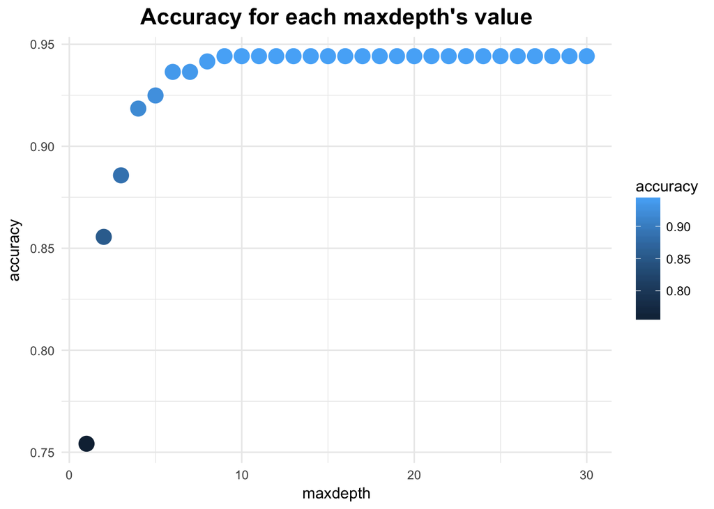

```r
accuracy <- c()
set.seed(123)
for (i in var) {
decision_tree <- rpart(formula = FormulaCART,
                      method="class",
                      data=training_set,
                      control = rpart.control(minbucket = 6, maxdepth = i))
letter_prediction_CART <- predict(decision_tree,
                                  test_set,
                                  type="class")
confusion_matrix_CART <- confusionMatrix(letter_prediction_CART, test_set$IsB)
accuracy[i] <- confusion_matrix_CART$overall[1]
}
df <-data.frame(maxdepth=var)
df$Accuracy <- accuracy
ggplot(df, aes(maxdepth,accuracy, color=accuracy)) +geom_point(shape = 16, size = 5, show.legend = T)+theme_minimal()+ggtitle("Accuracy for each maxdepth's value") +
  theme(plot.title = element_text(hjust = 0.5, face="bold", size=16))
```

It emerges that 6 is the optimal value for **minbucket** and 9 is the optimal value for **maxdepth**. So we create the decision tree controlling the growth with the values found before.

```r
set.seed(123)
decision_tree <- rpart(formula = FormulaCART,
                      method="class",
                      data=training_set,
                      control = rpart.control(minbucket=6, maxdepth = 9))
printcp(decision_tree)
```

```
##
## Classification tree:
## rpart(formula = FormulaCART, data = training_set, method = "class",
##     control = rpart.control(minbucket = 6, maxdepth = 9))
##
## Variables actually used in tree construction:
##  [1] Width     X2Ybar    X2bar     XY2bar    XYbar     Xbox      Xedge
##  [8] XedgeYcor Y2bar     Ybox      Yedge     YedgeXcor
##
## Root node error: 383/1558 = 0.24583
##
## n= 1558
##
##          CP nsplit rel error  xerror     xstd
## 1  0.215405      0   1.00000 1.00000 0.044375
## 2  0.058747      2   0.56919 0.56136 0.035545
## 3  0.027415      4   0.45170 0.51958 0.034400
## 4  0.026110      6   0.39687 0.48825 0.033493
## 5  0.022193      7   0.37076 0.47258 0.033024
## 6  0.019582      9   0.32637 0.43081 0.031713
## 7  0.018277     11   0.28721 0.36554 0.029473
## 8  0.015666     14   0.23238 0.31070 0.027373
## 9  0.013055     15   0.21671 0.30548 0.027161
## 10 0.011749     16   0.20366 0.30026 0.026946
## 11 0.010000     18   0.18016 0.28460 0.026288
```

```r
letter_prediction_CART <- predict(decision_tree,
                                  test_set,
                                  type="class")
confusionMatrix(letter_prediction_CART, test_set$IsB)
```

```
## Confusion Matrix and Statistics
##
##           Reference
## Prediction   No  Yes
##        No  1142   54
##        Yes   33  329
##
##                Accuracy : 0.9442
##                  95% CI : (0.9316, 0.955)
##     No Information Rate : 0.7542
##     P-Value [Acc > NIR] : < 2e-16
##
##                   Kappa : 0.8466
##  Mcnemar's Test P-Value : 0.03201
##
##             Sensitivity : 0.9719
##             Specificity : 0.8590
##          Pos Pred Value : 0.9548
##          Neg Pred Value : 0.9088
##              Prevalence : 0.7542
##          Detection Rate : 0.7330
##    Detection Prevalence : 0.7677
##       Balanced Accuracy : 0.9155
##
##        'Positive' Class : No
##
```

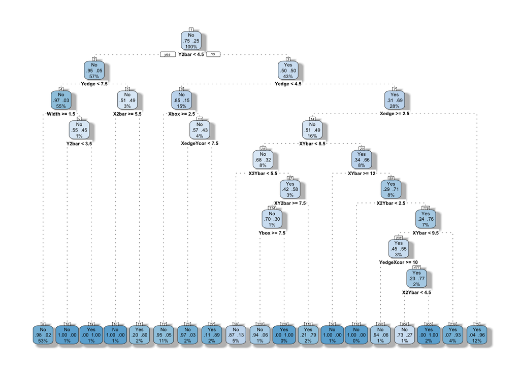

```r
rpart.plot(decision_tree,
           extra=104,
           box.palette="BuBu",
           branch.lty=3,
           shadow.col="grey",
           nn=TRUE)
```

It is useful to apply the model also to the training set to compare and verify the results

```r
letter_prediction_CART <- predict(decision_tree,
                                  training_set,
                                  type="class")
confusionMatrix(letter_prediction_CART, training_set$IsB)
```

```
## Confusion Matrix and Statistics
##
##           Reference
## Prediction   No  Yes
##        No  1150   44
##        Yes   25  339
##
##                Accuracy : 0.9557
##                  95% CI : (0.9443, 0.9654)
##     No Information Rate : 0.7542
##     P-Value [Acc > NIR] : < 2e-16
##
##                   Kappa : 0.8785
##  Mcnemar's Test P-Value : 0.03024
##
##             Sensitivity : 0.9787
##             Specificity : 0.8851
##          Pos Pred Value : 0.9631
##          Neg Pred Value : 0.9313
##              Prevalence : 0.7542
##          Detection Rate : 0.7381
##    Detection Prevalence : 0.7664
##       Balanced Accuracy : 0.9319
##
##        'Positive' Class : No
##
```

$Accuracy=0.9442$ on `test set`

$Accuracy=0.9557$ on `training set`

It’s easy to see that there’s a decrease of the $Accuracy$ on the `test set` but it’s not so relevant.

- Now, build a random forest model to predict whether or not the letter is a B. Again, select reasonable parameter values for the model, and justify your parameter choices. What is the accuracy of the model on the test set?

For the **nodesize** value wee keep the same value found for the CART built before. So we have $nodesize=6$ (same as **minbucket**) and we will find the optimal value of **ntree** by iterating the procedure.

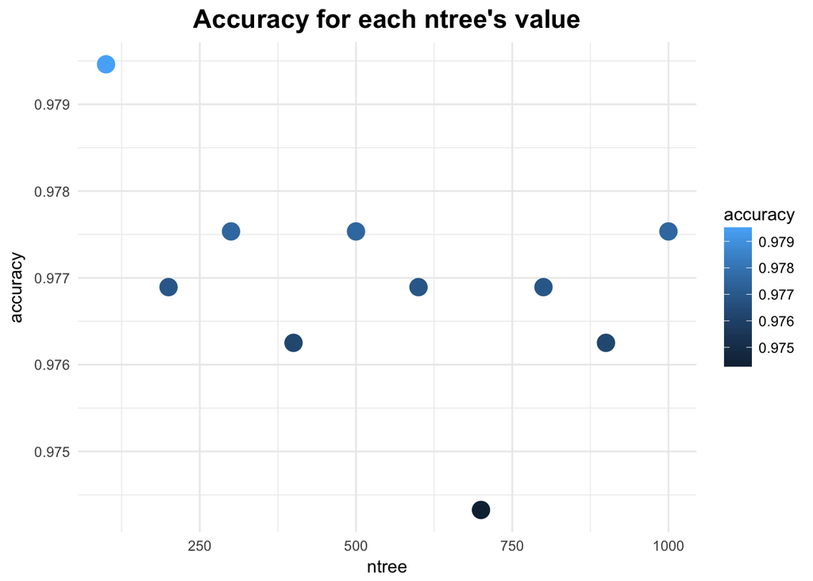

```r
var <- seq(from = 100, 1000, 100)
accuracy <- c()
set.seed(123)
for (i in var) {
random_forest <- randomForest(formula = FormulaCART,
                             data = training_set,
                             ntree= i,
                             nodesize=6)
letter_prediction_forest <- predict(random_forest, test_set)
confusion_matrix_forest <- confusionMatrix(letter_prediction_forest, test_set$IsB)
accuracy[(i/100)] <- confusion_matrix_forest$overall[1]
}
df <-data.frame(ntree=var)
df$Accuracy <- accuracy
ggplot(df, aes(ntree,accuracy, color=accuracy)) +geom_point(shape = 16, size = 5, show.legend = T)+theme_minimal()+ggtitle("Accuracy for each ntree's value") +
  theme(plot.title = element_text(hjust = 0.5, face="bold", size=16))
```

It emerges that the optimal number of trees for our model is 100. So we can proceed and let the forest grow!

```r
set.seed(123)
random_forest <- randomForest(formula = FormulaCART,
                             data = training_set,
                             ntree= 100,
                             nodesize=6)
letter_prediction_forest <- predict(random_forest, test_set)
confusionMatrix(letter_prediction_forest, test_set$IsB)
```

```
## Confusion Matrix and Statistics
##
##           Reference
## Prediction   No  Yes
##        No  1167   24
##        Yes    8  359
##
##                Accuracy : 0.9795
##                  95% CI : (0.9711, 0.9859)
##     No Information Rate : 0.7542
##     P-Value [Acc > NIR] : < 2e-16
##
##                   Kappa : 0.9438
##  Mcnemar's Test P-Value : 0.00801
##
##             Sensitivity : 0.9932
##             Specificity : 0.9373
##          Pos Pred Value : 0.9798
##          Neg Pred Value : 0.9782
##              Prevalence : 0.7542
##          Detection Rate : 0.7490
##    Detection Prevalence : 0.7644
##       Balanced Accuracy : 0.9653
##
##        'Positive' Class : No
##
```

```r
letter_prediction_forest <- predict(random_forest, training_set)
confusionMatrix(letter_prediction_forest, training_set$IsB)
```

```
## Confusion Matrix and Statistics
##
##           Reference
## Prediction   No  Yes
##        No  1174    0
##        Yes    1  383
##
##                Accuracy : 0.9994
##                  95% CI : (0.9964, 1)
##     No Information Rate : 0.7542
##     P-Value [Acc > NIR] : <2e-16
##
##                   Kappa : 0.9983
##  Mcnemar's Test P-Value : 1
##
##             Sensitivity : 0.9991
##             Specificity : 1.0000
##          Pos Pred Value : 1.0000
##          Neg Pred Value : 0.9974
##              Prevalence : 0.7542
##          Detection Rate : 0.7535
##    Detection Prevalence : 0.7535
##       Balanced Accuracy : 0.9996
##
##        'Positive' Class : No
##
```

$Accuracy=0.9795$ on `test set`

$Accuracy=0.9994$ on `training set`

- Compare the accuracy of your CART and Random Forest models. Which one performs better? For this application, do you think interpretability or accuracy is more important?

$Accuracy=0.9442$ is the score for the **CART** model on `test set`

$Accuracy=0.9795$ is the score for the **Random Forest** model on `test set`

The method that performs better is the **Random Forest** one. In this case the $Accuracy$ in more important than $Interpretability$

## Building a more general predictor

- In a multi-class classification problem, a simple baseline model is to predict the most frequent class of all of the options for every observation. For this problem, what does the baseline method predict, and what is the baseline accuracy on the testing set? Do you think this simple baseline method is a useful benchmark for this problem? Why or why not?

```r
summary(training_set$Letter)
```

```
##   A   B   P   R
## 389 383 401 385
```

As we can see, the letter P is the most frequent one in the `training set`, so we predict all the occurencies int the column `Letter` as P and we’ll compute the $Accuracy$ of this baseline method in order to see if it’s a useful benchmark.

```r
test_set$P <- "P"
confusionMatrix(test_set$P, test_set$Letter)
```

```
## Confusion Matrix and Statistics
##
##           Reference
## Prediction   A   B   P   R
##          A   0   0   0   0
##          B   0   0   0   0
##          P 400 383 402 373
##          R   0   0   0   0
##
## Overall Statistics
##
##                Accuracy : 0.258
##                  95% CI : (0.2364, 0.2805)
##     No Information Rate : 0.258
##     P-Value [Acc > NIR] : 0.5097
##
##                   Kappa : 0
##  Mcnemar's Test P-Value : NA
##
## Statistics by Class:
##
##                      Class: A Class: B Class: P Class: R
## Sensitivity            0.0000   0.0000    1.000   0.0000
## Specificity            1.0000   1.0000    0.000   1.0000
## Pos Pred Value            NaN      NaN    0.258      NaN
## Neg Pred Value         0.7433   0.7542      NaN   0.7606
## Prevalence             0.2567   0.2458    0.258   0.2394
## Detection Rate         0.0000   0.0000    0.258   0.0000
## Detection Prevalence   0.0000   0.0000    1.000   0.0000
## Balanced Accuracy      0.5000   0.5000    0.500   0.5000
```

This baseline method is not useful to predict target column `Letter`. Infact the $Accuracy$ is very low (25.8%) and the variables in the dataset have almost the same frequncies; so predicting them all as the same most frequent letter is a useless benchmark.

- Now build a classification tree to predict **Letter**, using the training set to build your model. (Remember not to use the variable **IsB** in the model, as this is related to what we are trying to predict!) Select reasonable parameter values and justify your parameter choices. What is the test set accuracy of your CART model? (HINT: When you are computing the test set accuracy using a classification matrix, you want to add everything on the main diagonal and divide by the total number of observations in the test set.)

```r
NewFormulaCART <- Letter ~ Xbox + Ybox + Width + Height + Onpix + Xbar + Ybar + X2bar + Y2bar + XYbar + X2Ybar + XY2bar + Xedge + XedgeYcor + Yedge + YedgeXcor
```

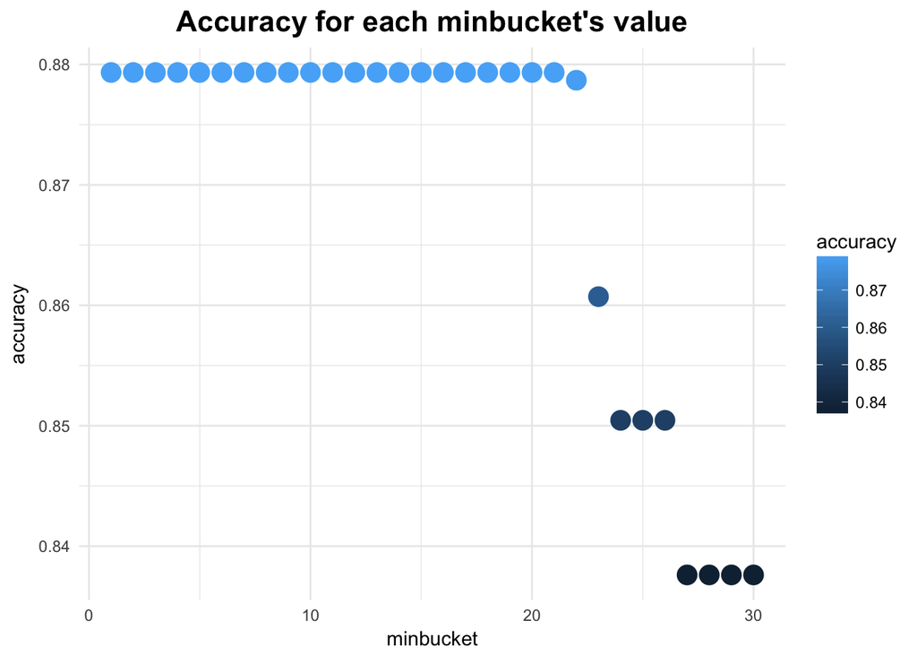

```r
var <- seq(from = 1, 30,1)
accuracy = c()
set.seed(123)
for (i in var) {
general_decision_tree <- rpart(formula = NewFormulaCART,
                              method="class",
                              data=training_set,
                              control = rpart.control(minbucket = i))
new_letter_prediction_CART <- predict(general_decision_tree,
                                      test_set,
                                      type="class")
confusion_matrix_CART <- confusionMatrix(new_letter_prediction_CART, test_set$Letter)
accuracy[i] <- confusion_matrix_CART$overall[1]
}
df <-data.frame(minbucket=var)
df$Accuracy <- accuracy
ggplot(df, aes(minbucket,accuracy, color=accuracy)) +geom_point(shape = 16, size = 5, show.legend = T)+theme_minimal()+ggtitle("Accuracy for each minbucket's value") +
  theme(plot.title = element_text(hjust = 0.5, face="bold", size=16))
```

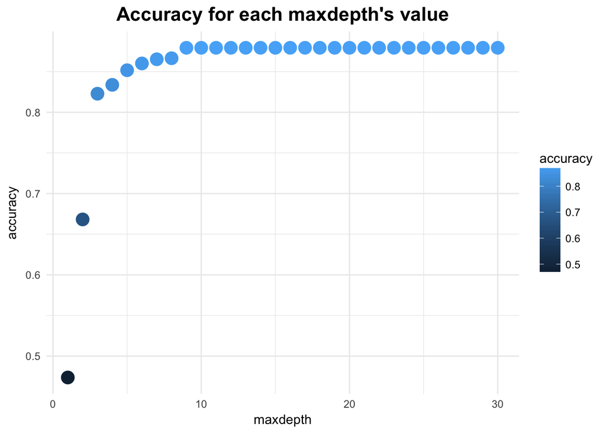

```r
accuracy <- c()
set.seed(123)
for (i in var) {
general_decision_tree <- rpart(formula = NewFormulaCART,
                              method="class",
                              data=training_set,
                              control = rpart.control(minbucket = 21, maxdepth = i))
new_letter_prediction_CART <- predict(general_decision_tree,
                                      test_set,
                                      type="class")
confusion_matrix_CART <- confusionMatrix(new_letter_prediction_CART, test_set$Letter)
accuracy[i] <- confusion_matrix_CART$overall[1]
}
df <-data.frame(maxdepth=var)
df$Accuracy <- accuracy
ggplot(df, aes(maxdepth,accuracy, color=accuracy)) +geom_point(shape = 16, size = 5, show.legend = T)+theme_minimal()+ggtitle("Accuracy for each maxdepth's value") +
  theme(plot.title = element_text(hjust = 0.5, face="bold", size=16))
```

It emerges that 21 is the optimal value for **minbucket** and 9 is the optimal value for **maxdepth**. So we create the decision tree controlling the growth with the values found before.

```r
set.seed(123)
general_decision_tree <- rpart(formula = NewFormulaCART,
                              method="class",
                              data=training_set,
                              control = rpart.control(minbucket = 21, maxdepth = 9))
printcp(general_decision_tree)
```

```
##
## Classification tree:
## rpart(formula = NewFormulaCART, data = training_set, method = "class",
##     control = rpart.control(minbucket = 21, maxdepth = 9))
##
## Variables actually used in tree construction:
## [1] X2bar     XY2bar    Xedge     XedgeYcor Y2bar     Ybar      Yedge
##
## Root node error: 1157/1558 = 0.74262
##
## n= 1558
##
##         CP nsplit rel error  xerror     xstd
## 1 0.277442      0   1.00000 1.03889 0.014324
## 2 0.276577      1   0.72256 0.58859 0.016922
## 3 0.194468      2   0.44598 0.46586 0.016228
## 4 0.014693      3   0.25151 0.24978 0.013261
## 5 0.013829      4   0.23682 0.22558 0.012740
## 6 0.013397      5   0.22299 0.22558 0.012740
## 7 0.010372      8   0.18237 0.19706 0.012058
## 8 0.010000     11   0.15125 0.19447 0.011992
```

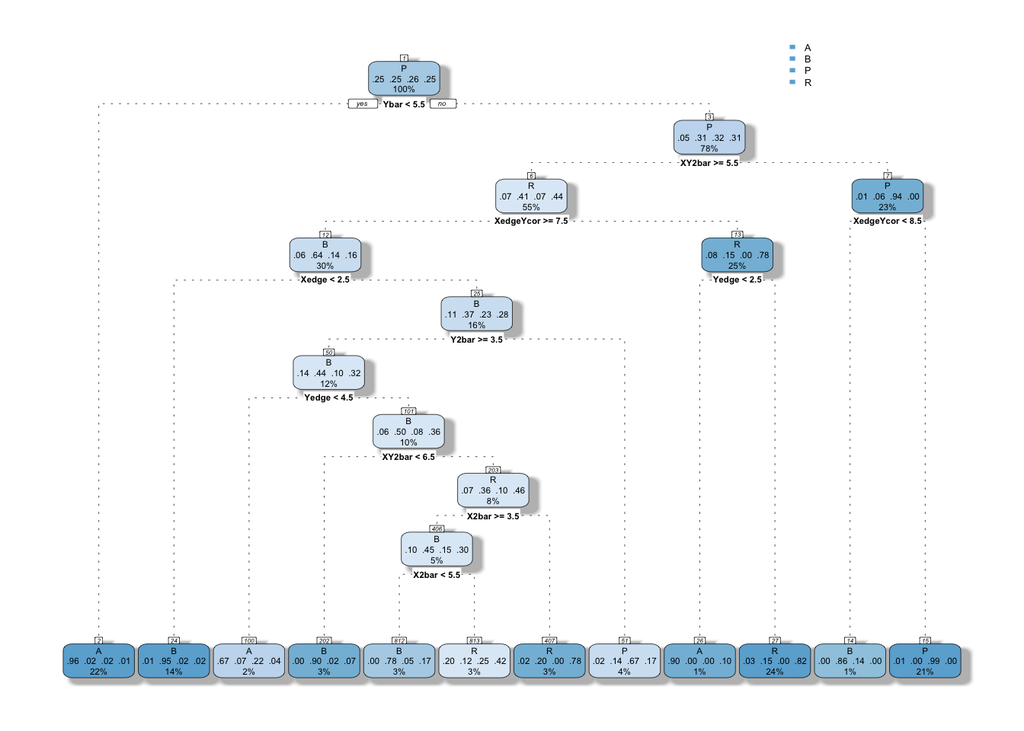

```r
rpart.plot(general_decision_tree,
           extra=104,
           box.palette="BuBu",
           branch.lty=3,
           shadow.col="grey",
           nn=TRUE)
```

```r
new_letter_prediction_CART <- predict(general_decision_tree,
                                      test_set,
                                      type="class")
confusionMatrix(new_letter_prediction_CART, test_set$Letter)
```

```
## Confusion Matrix and Statistics
##
##           Reference
## Prediction   A   B   P   R
##          A 372  14   9  11
##          B   5 292  11  17
##          P   0  14 373  12
##          R  23  63   9 333
##
## Overall Statistics
##
##                Accuracy : 0.8793
##                  95% CI : (0.8621, 0.8951)
##     No Information Rate : 0.258
##     P-Value [Acc > NIR] : < 2.2e-16
##
##                   Kappa : 0.8391
##  Mcnemar's Test P-Value : 5.278e-08
##
## Statistics by Class:
##
##                      Class: A Class: B Class: P Class: R
## Sensitivity            0.9300   0.7624   0.9279   0.8928
## Specificity            0.9706   0.9719   0.9775   0.9198
## Pos Pred Value         0.9163   0.8985   0.9348   0.7780
## Neg Pred Value         0.9757   0.9262   0.9750   0.9646
## Prevalence             0.2567   0.2458   0.2580   0.2394
## Detection Rate         0.2388   0.1874   0.2394   0.2137
## Detection Prevalence   0.2606   0.2086   0.2561   0.2747
## Balanced Accuracy      0.9503   0.8672   0.9527   0.9063
```

```r
new_letter_prediction_CART <- predict(general_decision_tree,
                                      training_set,
                                      type="class")
confusionMatrix(new_letter_prediction_CART, training_set$Letter)
```

```
## Confusion Matrix and Statistics
##
##           Reference
## Prediction   A   B   P   R
##          A 364   8  12   5
##          B   2 295  11  14
##          P   3   9 368  10
##          R  20  71  10 356
##
## Overall Statistics
##
##                Accuracy : 0.8877
##                  95% CI : (0.8709, 0.9029)
##     No Information Rate : 0.2574
##     P-Value [Acc > NIR] : < 2.2e-16
##
##                   Kappa : 0.8502
##  Mcnemar's Test P-Value : 2.39e-10
##
## Statistics by Class:
##
##                      Class: A Class: B Class: P Class: R
## Sensitivity            0.9357   0.7702   0.9177   0.9247
## Specificity            0.9786   0.9770   0.9810   0.9139
## Pos Pred Value         0.9357   0.9161   0.9436   0.7790
## Neg Pred Value         0.9786   0.9288   0.9717   0.9737
## Prevalence             0.2497   0.2458   0.2574   0.2471
## Detection Rate         0.2336   0.1893   0.2362   0.2285
## Detection Prevalence   0.2497   0.2067   0.2503   0.2933
## Balanced Accuracy      0.9572   0.8736   0.9493   0.9193
```

$Accuracy=0.8793$ on `test set`

$Accuracy=0.8877$ on `training set`

- Now, build a random forest model to predict **Letter**, using the training data - again, do not forget to remove the **IsB** variable. What is the test set accuracy of your random forest model?

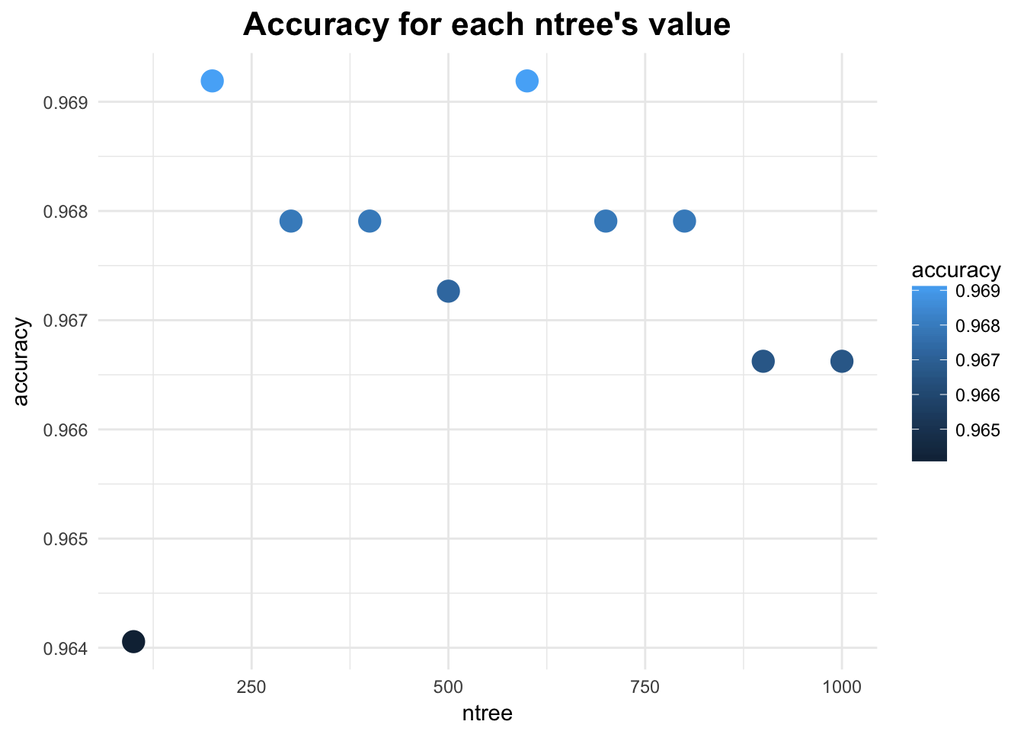

```r
var <- seq(from = 100, 1000, 100)
accuracy <- c()
set.seed(123)
for (i in var) {
general_random_forest <- randomForest(formula = NewFormulaCART,
                             data = training_set,
                             ntree= i,
                             nodesize=21)
new_letter_prediction_forest <- predict(general_random_forest, test_set)
confusion_matrix_forest <- confusionMatrix(new_letter_prediction_forest, test_set$Letter)
accuracy[(i/100)] <- confusion_matrix_forest$overall[1]
}
df <-data.frame(ntree=var)
df$Accuracy <- accuracy
ggplot(df, aes(ntree,accuracy, color=accuracy)) +geom_point(shape = 16, size = 5, show.legend = T)+theme_minimal()+ggtitle("Accuracy for each ntree's value") +
  theme(plot.title = element_text(hjust = 0.5, face="bold", size=16))
```

It emerges that the optimal number of trees in this case for our model is 200. So we can proceed and let the forest grow!

```r
set.seed(123)
general_random_forest <- randomForest(formula = NewFormulaCART,
                                     data = training_set,
                                     ntree=200,
                                     nodesize=21)
general_random_forest
```

```
##
## Call:
##  randomForest(formula = NewFormulaCART, data = training_set, ntree = 200,      nodesize = 21)
##                Type of random forest: classification
##                      Number of trees: 200
## No. of variables tried at each split: 4
##
##         OOB estimate of  error rate: 3.98%
## Confusion matrix:
##     A   B   P   R class.error
## A 382   0   5   2  0.01799486
## B   0 362   6  15  0.05483029
## P   1   9 389   2  0.02992519
## R   0  22   0 363  0.05714286
```

```r
new_letter_prediction_forest <- predict(general_random_forest, test_set)
confusionMatrix(new_letter_prediction_forest, test_set$Letter)
```

```
## Confusion Matrix and Statistics
##
##           Reference
## Prediction   A   B   P   R
##          A 395   0   1   4
##          B   0 369   4  22
##          P   2   1 395   0
##          R   3  13   2 347
##
## Overall Statistics
##
##                Accuracy : 0.9666
##                  95% CI : (0.9565, 0.975)
##     No Information Rate : 0.258
##     P-Value [Acc > NIR] : < 2.2e-16
##
##                   Kappa : 0.9555
##  Mcnemar's Test P-Value : NA
##
## Statistics by Class:
##
##                      Class: A Class: B Class: P Class: R
## Sensitivity            0.9875   0.9634   0.9826   0.9303
## Specificity            0.9957   0.9779   0.9974   0.9848
## Pos Pred Value         0.9875   0.9342   0.9925   0.9507
## Neg Pred Value         0.9957   0.9880   0.9940   0.9782
## Prevalence             0.2567   0.2458   0.2580   0.2394
## Detection Rate         0.2535   0.2368   0.2535   0.2227
## Detection Prevalence   0.2567   0.2535   0.2555   0.2343
## Balanced Accuracy      0.9916   0.9707   0.9900   0.9576
```

```r
new_letter_prediction_forest <- predict(general_random_forest, training_set)
confusionMatrix(new_letter_prediction_forest, training_set$Letter)
```

```
## Confusion Matrix and Statistics
##
##           Reference
## Prediction   A   B   P   R
##          A 388   0   0   0
##          B   0 376   4  11
##          P   1   1 396   0
##          R   0   6   1 374
##
## Overall Statistics
##
##                Accuracy : 0.9846
##                  95% CI : (0.9772, 0.9901)
##     No Information Rate : 0.2574
##     P-Value [Acc > NIR] : < 2.2e-16
##
##                   Kappa : 0.9795
##  Mcnemar's Test P-Value : NA
##
## Statistics by Class:
##
##                      Class: A Class: B Class: P Class: R
## Sensitivity            0.9974   0.9817   0.9875   0.9714
## Specificity            1.0000   0.9872   0.9983   0.9940
## Pos Pred Value         1.0000   0.9616   0.9950   0.9816
## Neg Pred Value         0.9991   0.9940   0.9957   0.9907
## Prevalence             0.2497   0.2458   0.2574   0.2471
## Detection Rate         0.2490   0.2413   0.2542   0.2401
## Detection Prevalence   0.2490   0.2510   0.2555   0.2445
## Balanced Accuracy      0.9987   0.9845   0.9929   0.9827
```

$Accuracy=0.9666$ on `test set`

$Accuracy=0.9846$ on `training set`

- Compare the accuracy of your CART and Random Forest models for this problem. Which one would you recommend for this problem? Is your choice different from the model you recommended for letter B?

$Accuracy=0.8793$ is the score for the **CART** model on `test set`

$Accuracy=0.9666$ is the score for the **Random Forest** model on `test set`

In this case, in order to maximise the $Accuracy$, the recommended method to solve this problem in the **Random Forest**, which is the same that performed better before during the more specific classification problem.